# 0. Data audit, EDA, and the subsampling decision

Airline Customer Satisfaction — Bayesian Learning project

## 1. Import and cleanup

We start, as usual, by clearing the workspace and fixing the seed for reproducibility.

```r
rm(list = ls())
set.seed(2026)

library(dplyr)
library(tidyr)
library(ggplot2)
library(RColorBrewer)
```

The source file has 22 columns whose original names contain spaces and slashes (`"Departure/Arrival time convenient"`, `"Departure Delay in Minutes"`, …). We rename them once, right away, to short `snake_case` names: every later section (conjugate model, JAGS, BAS, …) then refers to the same clean names instead of re-deriving them each time.

```r
raw <- read.csv("Airline_customer_satisfaction.csv", stringsAsFactors = FALSE)

new_names <- c(
  "satisfaction", "customer_type", "age", "travel_type", "cabin_class",
  "flight_distance", "seat_comfort", "time_convenient", "food_drink",
  "gate_location", "wifi", "entertainment", "online_support", "ease_booking",
  "onboard_service", "legroom", "baggage", "checkin", "cleanliness",
  "online_boarding", "dep_delay", "arr_delay"
)
names(raw) <- new_names

dim(raw)
```

```
## [1] 129880     22
```

## 2. Data audit

A quick pass over structure, duplicates and missingness before anything else.

```r
str(raw)
```

```
## 'data.frame':    129880 obs. of  22 variables:
##  $ satisfaction   : chr  "satisfied" "satisfied" "satisfied" "satisfied" ...
##  $ customer_type  : chr  "Loyal Customer" "Loyal Customer" "Loyal Customer" "Loyal Customer" ...
##  $ age            : int  65 47 15 60 70 30 66 10 56 22 ...
##  $ travel_type    : chr  "Personal Travel" "Personal Travel" "Personal Travel" "Personal Travel" ...
##  $ cabin_class    : chr  "Eco" "Business" "Eco" "Eco" ...
##  $ flight_distance: int  265 2464 2138 623 354 1894 227 1812 73 1556 ...
##  $ seat_comfort   : int  0 0 0 0 0 0 0 0 0 0 ...
##  $ time_convenient: int  0 0 0 0 0 0 0 0 0 0 ...
##  $ food_drink     : int  0 0 0 0 0 0 0 0 0 0 ...
##  $ gate_location  : int  2 3 3 3 3 3 3 3 3 3 ...
##  $ wifi           : int  2 0 2 3 4 2 2 2 5 2 ...
##  $ entertainment  : int  4 2 0 4 3 0 5 0 3 0 ...
##  $ online_support : int  2 2 2 3 4 2 5 2 5 2 ...
##  $ ease_booking   : int  3 3 2 1 2 2 5 2 4 2 ...
##  $ onboard_service: int  3 4 3 1 2 5 5 3 4 2 ...
##  $ legroom        : int  0 4 3 0 0 4 0 3 0 4 ...
##  $ baggage        : int  3 4 4 1 2 5 5 4 1 5 ...
##  $ checkin        : int  5 2 4 4 4 5 5 5 5 3 ...
##  $ cleanliness    : int  3 3 4 1 2 4 5 4 4 4 ...
##  $ online_boarding: int  2 2 2 3 5 2 3 2 4 2 ...
##  $ dep_delay      : int  0 310 0 0 0 0 17 0 0 30 ...
##  $ arr_delay      : num  0 305 0 0 0 0 15 0 0 26 ...
```

```r
cat("Duplicated rows:", sum(duplicated(raw)), "\n")
```

```
## Duplicated rows: 0
```

```r
na_counts <- colSums(is.na(raw))
na_counts[na_counts > 0]
```

```
## arr_delay
##       393
```

The only missingness in the whole dataset is in `arr_delay` (393 rows, 0.3% of the data) — trivial to handle, we deal with it in Section 4.

The 14 service-quality items are Likert-type ratings; we check they all lie in the advertised 0-5 range.

```r
ordinal_vars <- c("seat_comfort", "time_convenient", "food_drink", "gate_location",
                   "wifi", "entertainment", "online_support", "ease_booking",
                   "onboard_service", "legroom", "baggage", "checkin",
                   "cleanliness", "online_boarding")

sapply(raw[ordinal_vars], range)
```

```
##      seat_comfort time_convenient food_drink gate_location wifi entertainment
## [1,]            0               0          0             0    0             0
## [2,]            5               5          5             5    5             5
##      online_support ease_booking onboard_service legroom baggage checkin
## [1,]              0            0               0       0       1       0
## [2,]              5            5               5       5       5       5
##      cleanliness online_boarding
## [1,]           0               0
## [2,]           5               5
```

All items range over 0-5 (`baggage` never actually hits 0). The remaining numeric variables also look sane: `age` in [7, 85], `flight_distance` in [50, 6951] miles, and both delay variables non-negative.

We convert the four categorical variables to factors, fixing a natural order for `cabin_class` (used again in Section 2, where we compare a nominal-dummy vs. an ordinal-score encoding of class).

```r
raw$satisfaction  <- factor(raw$satisfaction, levels = c("dissatisfied", "satisfied"))
raw$customer_type <- factor(raw$customer_type)
raw$travel_type   <- factor(raw$travel_type)
raw$cabin_class   <- factor(raw$cabin_class, levels = c("Eco", "Eco Plus", "Business"))

round(prop.table(table(raw$satisfaction)), 3)
```

```
##
## dissatisfied    satisfied
##        0.453        0.547
```

The response is close to balanced (54.7% satisfied), which is exactly the regime where a simple Bernoulli/logistic likelihood is appropriate no need for anything fancier to handle imbalance.

We now drop the 393 rows with missing `arr_delay` (0.3% of the data: dropping is simpler than imputing and changes nothing of substance) and carry a `row_id` along, which will make the train/test split in Section 5 trivial to construct.

```r
data <- raw %>% filter(!is.na(arr_delay))
data$row_id <- seq_len(nrow(data))
nrow(data)
```

```
## [1] 129487
```

## 3. Exploratory analysis

### 3.1 Overall correlation

```r
# modify categorical variables in order to run correlation

num.data = data
cat_vars = names(num.data)[!sapply(num.data, is.numeric)]

mappings <- lapply(num.data[cat_vars], levels)
num.data[cat_vars] <- lapply(num.data[cat_vars], as.integer)
```

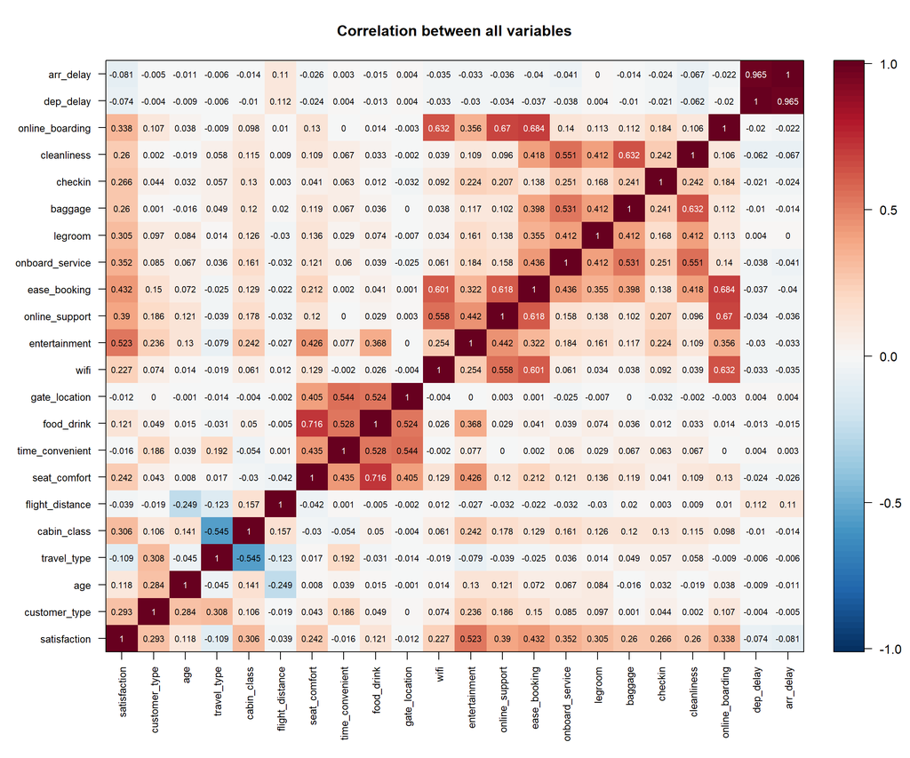

```r
plot_corr_heatmap <- function(mat, labels = colnames(mat), title = "Correlation matrix", show_values=TRUE, digits_to_show=3) {
  pal <- colorRampPalette(rev(brewer.pal(11, "RdBu")))(100)
  layout(matrix(c(1, 2), nrow = 1), widths = c(9, 1))
  par(mar = c(7, 7, 4, 1))
  image(1:ncol(mat), 1:ncol(mat), mat,
        xlab = "", ylab = "", main = title,
        col = pal, zlim = c(-1, 1), axes = FALSE)
  axis(1, 1:ncol(mat), labels, las = 2, cex.axis = 0.8)
  axis(2, 1:ncol(mat), labels, las = 2, cex.axis = 0.8)
  box()

  # show correltion values within boxes
  if (show_values) {
    grid <- expand.grid(i = 1:nrow(mat), j = 1:ncol(mat))
    val  <- mat[cbind(grid$i, grid$j)]

    # switch between white and black text based on cell brightness, to improve redability
    idx <- findInterval(val, seq(-1, 1, length.out = length(pal) + 1),
                        all.inside = TRUE)
    cell_rgb <- col2rgb(pal[idx])
    lum <- 0.299 * cell_rgb[1, ] + 0.587 * cell_rgb[2, ] + 0.114 * cell_rgb[3, ]
    txt_col <- ifelse(lum < 128, "white", "black")

    text(grid$i, grid$j, labels = round(val, digits_to_show),
         cex = 0.7, col = txt_col)
  }

  # colorbar
  par(mar = c(7, 1, 4, 3))
  z <- seq(-1, 1, length.out = 100)
  image(1, z, matrix(z, nrow = 1), col = pal, axes = FALSE, xlab = "", ylab = "")
  axis(4, las = 2)
  box()
}

corr_mat = cor(num.data[, !names(num.data) == "row_id"])
plot_corr_heatmap(corr_mat, title = "Correlation between all variables")
```

### 3.2 Correlation between the 14 service items

The 14 ordinal items are the core covariates for the horseshoe model in Section 3 of the project, so it matters whether they are independent. We reuse the correlation-heatmap recipe from the JAGS lab notes (`image()` + `RColorBrewer`, rather than pulling in a new plotting package just for this).

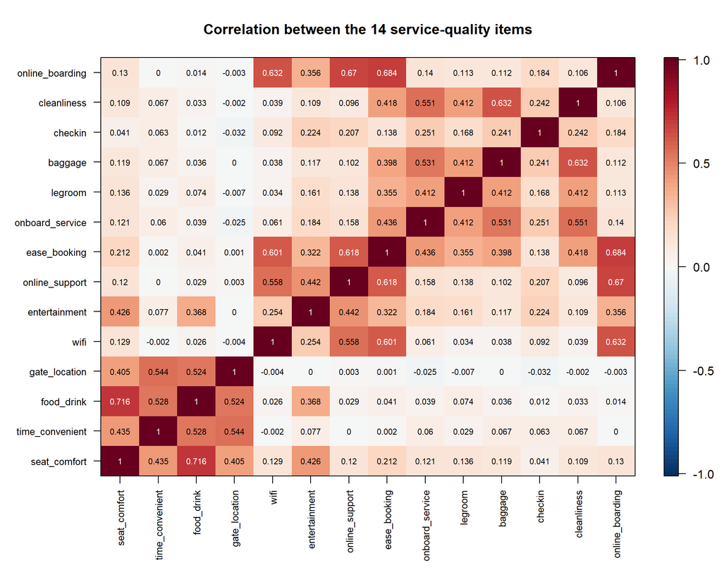

```r
ord_corr_mat <- cor(data[ordinal_vars])
plot_corr_heatmap(ord_corr_mat, title = "Correlation between the 14 service-quality items")
```

None of this is surprising, but it is exactly the justification for the horseshoe shrinkage prior later: several of these 14 covariates are near-substitutes for one another, so a model that shrinks the redundant ones towards zero is preferable to plain vague-prior logistic regression with all 14 included.

### 3.2 A few service items, by satisfaction

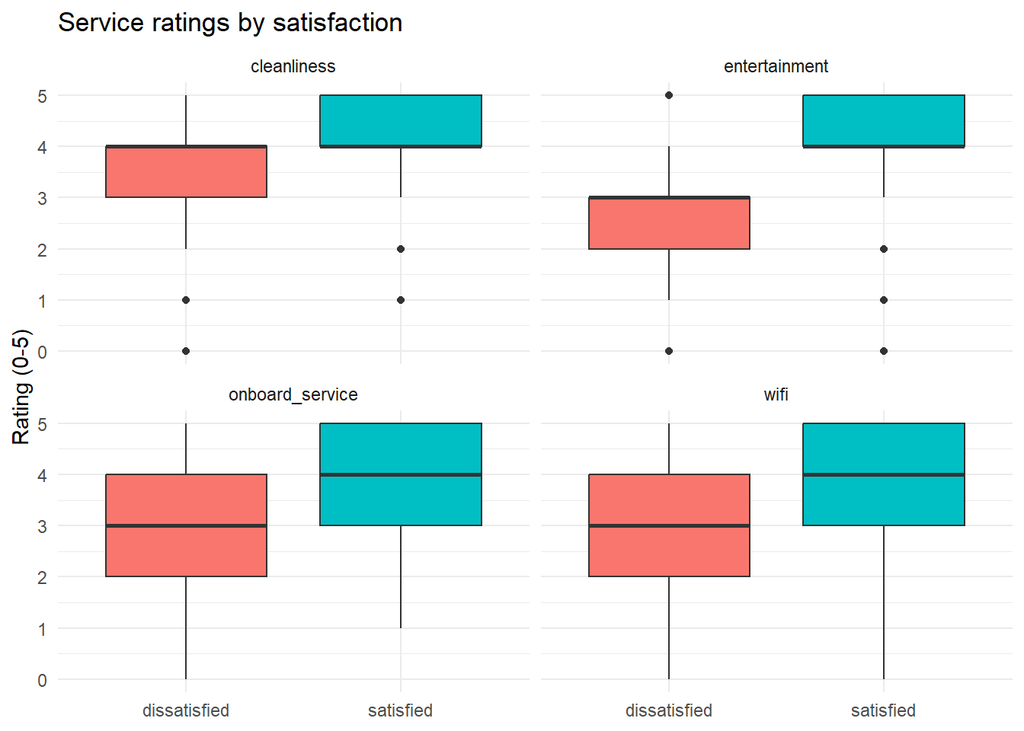

```r
box_df <- data %>%
  select(satisfaction, wifi, entertainment, onboard_service, cleanliness) %>%
  pivot_longer(-satisfaction, names_to = "item", values_to = "rating")

ggplot(box_df, aes(x = satisfaction, y = rating, fill = satisfaction)) +
  geom_boxplot(show.legend = FALSE) +
  facet_wrap(~ item) +
  labs(title = "Service ratings by satisfaction", x = NULL, y = "Rating (0-5)") +
  theme_minimal()
```

## 4. The delay pair: decorrelating arrival from departure delay

```r
cor(data$dep_delay, data$arr_delay)
```

```
## [1] 0.9652912
```

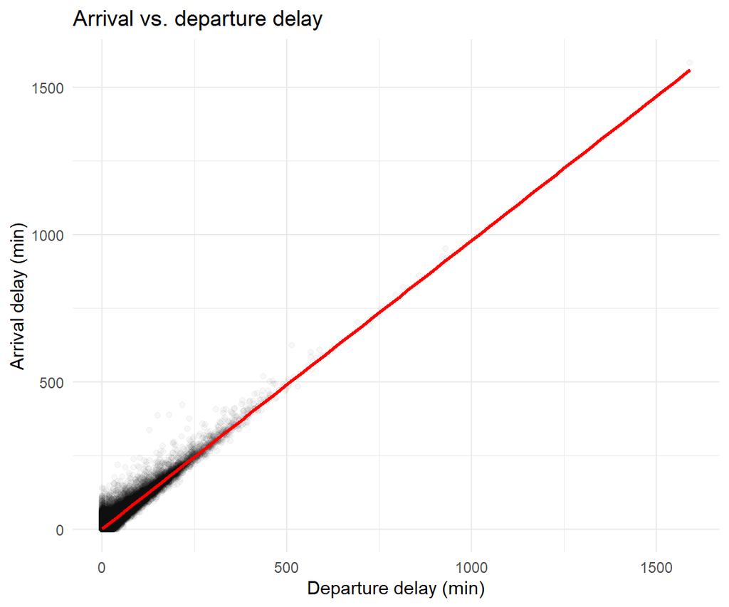

```r
ggplot(data, aes(x = dep_delay, y = arr_delay)) +
  geom_point(alpha = 0.03) +
  geom_smooth(method = "lm", se = FALSE, color = "red") +
  labs(title = "Arrival vs. departure delay",
       x = "Departure delay (min)", y = "Arrival delay (min)") +
  theme_minimal()
```

A correlation of 0.965 means including both raw variables in a regression is close to duplicating one predictor — exactly the near-collinearity the horseshoe prior is meant to handle, but there is a cheaper fix for this *specific* pair. We regress `arr_delay` on `dep_delay` and keep the **residual** as a second covariate: by the defining property of least squares, a residual is orthogonal to every column of the design matrix used to produce it, so this new variable is uncorrelated with `dep_delay` *by construction* — no shrinkage prior needed to discover that.

```r
delay_fit <- lm(arr_delay ~ dep_delay, data = data)
data$arr_delay_extra <- resid(delay_fit)

cor(data$arr_delay_extra, data$dep_delay)
```

```
## [1] -1.974482e-15
```

As a sanity check, this is nearly the same information as the naive `arr_delay - dep_delay` “minutes gained or lost in the air”, since the estimated slope is close to 1:

```r
coef(delay_fit)
```

```
## (Intercept)   dep_delay
##   0.7574643   0.9788491
```

```r
excess <- data$arr_delay - data$dep_delay
cor(excess, data$arr_delay_extra)
```

```
## [1] 0.9968262
```

We keep `arr_delay_extra` (exactly orthogonal to `dep_delay`) rather than the naive difference (only approximately so) as the second delay covariate for Sections 2-3, alongside `dep_delay` itself.

## 5. Structural zeros

```r
zero_share <- sort(sapply(data[ordinal_vars], function(x) mean(x == 0)), decreasing = TRUE)
round(zero_share, 4)
```

```
## time_convenient      food_drink    seat_comfort   entertainment         legroom
##          0.0513          0.0457          0.0369          0.0229          0.0034
##            wifi    ease_booking online_boarding onboard_service     cleanliness
##          0.0010          0.0001          0.0001          0.0000          0.0000
##   gate_location  online_support         checkin         baggage
##          0.0000          0.0000          0.0000          0.0000
```

Four items — `time_convenient`, `food_drink`, `seat_comfort`, `entertainment` have a non-trivial block of zeros (2-5% of rows), well above the near-zero rates for the rest. A real “1” (very dissatisfied) and a coded “0” (not applicable, e.g. no in-flight entertainment on that aircraft) are different things, but disentangling them would need a zero-inflated / mixture likelihood for each item. We flag this here and treat it as a **robustness check** later (Section 5 of the project: refit excluding these rows and see whether conclusions move), rather than building extra model complexity into the main analysis now.

## 6. The subsampling decision

The full file has 129487 rows (after dropping the 393 with missing `arr_delay`), while the project brief describes a curated 1,000-row extract. We draw a **stratified** training subsample of $n\approx 1200$ — matching the brief’s intended scale and keeping every MCMC run in later sections fast — and keep essentially all remaining rows as a held-out test set for the prediction exercise in Section 6. Stratifying on `satisfaction` and `cabin_class` (6 strata) keeps the subsample representative of the population on exactly the variables the whole analysis is about.

```r
stratified_sample <- function(pop, strata_vars, n_target, seed = 2026) {
  set.seed(seed)
  frac <- n_target / nrow(pop)
  pop %>%
    group_by(across(all_of(strata_vars))) %>%
    slice_sample(prop = frac) %>%
    ungroup()
}

train <- stratified_sample(data, c("satisfaction", "cabin_class"), n_target = 1200, seed = 2026)
test  <- data %>% filter(!row_id %in% train$row_id)

nrow(train); nrow(test)
```

```
## [1] 1197
```

```
## [1] 128290
```

A quick check that the sampling did what it should: stratum shares in `train` should match the population shares closely.

```r
data   %>% count(satisfaction, cabin_class) %>% mutate(pop_share   = round(n / sum(n), 3)) %>% select(-n) %>%
  full_join(
    train %>% count(satisfaction, cabin_class) %>% mutate(train_share = round(n / sum(n), 3)) %>% select(-n),
    by = c("satisfaction", "cabin_class")
  )
```

```
##   satisfaction cabin_class pop_share train_share
## 1 dissatisfied         Eco     0.272       0.272
## 2 dissatisfied    Eco Plus     0.041       0.041
## 3 dissatisfied    Business     0.139       0.139
## 4    satisfied         Eco     0.177       0.177
## 5    satisfied    Eco Plus     0.031       0.031
## 6    satisfied    Business     0.340       0.340
```

They match to within a fraction of a percentage point in every stratum, as they should by the law of large numbers applied within each group.

## 7. Save the split for later sections

```r
dir.create("data", showWarnings = FALSE)
write.csv(train %>% select(-row_id), "data/train_subsample.csv", row.names = FALSE)
write.csv(test  %>% select(-row_id), "data/test_holdout.csv",   row.names = FALSE)
```

From Section 1 onward we simply read `data/train_subsample.csv` (fit) and `data/test_holdout.csv` (predict), so the subsampling never has to be redone.

## Summary

Before touching a single prior: the response is close to balanced, the 14 service ratings form 2-3 correlated blocks (motivating shrinkage rather than using all 14 naively), the two delay variables are near-duplicates (fixed by keeping `dep_delay` and an orthogonal residual `arr_delay_extra`), a handful of items carry a structural-zero block worth revisiting later, and a stratified ~1200-row training subsample keeps the MCMC-based sections fast while ~128290 held-out rows give a low-variance out-of-sample check.